# EDA for Final

2018/12/18

This is a simple overview for the raw data. First we need to import some packages.

```r
library(dplyr)
library(ggplot2)
```

## Dara Pre-process

### Raw Data

```r
cvs = read.csv("cvs_sales.csv", fileEncoding = "Big5", stringsAsFactors = F)
cvs$銷售日期 = as.Date(cvs$銷售日期)
cvs$weekday = weekdays(cvs$銷售日期)
head(cvs, 10)
```

```
##            門市   銷售日期 客戶編號 大分類          品號
## 1  1101瑞光藥局 2014-12-01  2851015      6 4903111379484
## 2  1101瑞光藥局 2014-12-01  2678305      6 4902430601559
## 3  1101瑞光藥局 2014-12-01  2678305      9      76006009
## 4  1101瑞光藥局 2014-12-01  2678305      9      77600048
## 5  1101瑞光藥局 2014-12-01  1816361      4 0651080366519
## 6  1101瑞光藥局 2014-12-01  1816361      4 0651080485067
## 7  1101瑞光藥局 2014-12-01  3154064      1 4962204176409
## 8  1101瑞光藥局 2014-12-01  3154064      8 4711916004865
## 9  1101瑞光藥局 2014-12-01  2661716      1 4713680399703
## 10 1101瑞光藥局 2014-12-01  2661716      2 4710637464002
##                                         品名 數量 營收 weekday
## 1  蘇菲超輕柔超薄護墊 天然無香(14cm) 40片/包    1   39  Monday
## 2                   幫寶適特級棉柔XL-36片/包    1  449  Monday
## 3                                       績點  -10    0  Monday
## 4                                       金幣   40    0  Monday
## 5                普雷克雙線美白牙線棒35支/包    1   60  Monday
## 6                普雷克兒童塗氟牙線棒48支/包    1  120  Monday
## 7                       e視界50點眼液15ml/瓶    1  180  Monday
## 8          信東歐可潔多功能保養液20ml*6支/包    1   65  Monday
## 9         生達盈盈綜合感冒膠囊 12粒/盒(麻登)    1  100  Monday
## 10                        得萊寶酵素錠3粒/包    6  174  Monday
```

structure of data aond summary

```r
str(cvs)
```

```
## 'data.frame':    1040231 obs. of  9 variables:
##  $ 門市    : chr  "1101瑞光藥局" "1101瑞光藥局" "1101瑞光藥局" "1101瑞光藥局" ...
##  $ 銷售日期: Date, format: "2014-12-01" "2014-12-01" ...
##  $ 客戶編號: int  2851015 2678305 2678305 2678305 1816361 1816361 3154064 3154064 2661716 2661716 ...
##  $ 大分類  : int  6 6 9 9 4 4 1 8 1 2 ...
##  $ 品號    : chr  "4903111379484" "4902430601559" "76006009" "77600048" ...
##  $ 品名    : chr  "蘇菲超輕柔超薄護墊 天然無香(14cm) 40片/包" "幫寶適特級棉柔XL-36片/包" "績點" "金幣" ...
##  $ 數量    : num  1 1 -10 40 1 1 1 1 1 6 ...
##  $ 營收    : int  39 449 0 0 60 120 180 65 100 174 ...
##  $ weekday : chr  "Monday" "Monday" "Monday" "Monday" ...
```

```r
summary(cvs)
```

```
##      門市              銷售日期             客戶編號           大分類
##  Length:1040231     Min.   :2014-12-01   Min.   :1511344   Min.   :1.000
##  Class :character   1st Qu.:2014-12-09   1st Qu.:1816361   1st Qu.:1.000
##  Mode  :character   Median :2014-12-16   Median :2563341   Median :6.000
##                     Mean   :2014-12-16   Mean   :2420896   Mean   :5.412
##                     3rd Qu.:2014-12-24   3rd Qu.:2915670   3rd Qu.:9.000
##                     Max.   :2014-12-31   Max.   :3214713   Max.   :9.000
##      品號               品名                數量
##  Length:1040231     Length:1040231     Min.   :-10680.000
##  Class :character   Class :character   1st Qu.:     1.000
##  Mode  :character   Mode  :character   Median :     1.000
##                                        Mean   :     2.052
##                                        3rd Qu.:     4.000
##                                        Max.   :  4705.000
##       營收            weekday
##  Min.   :-63000.0   Length:1040231
##  1st Qu.:     0.0   Class :character
##  Median :    60.0   Mode  :character
##  Mean   :   208.9
##  3rd Qu.:   198.0
##  Max.   : 63000.0
```

We have sales data for 9 categories, 118 stores during the entire December

```r
unique(cvs$門市)
```

```
##   [1] "1101瑞光藥局"           "1103中山林森店"
##   [3] "1104萬華昆明店"         "1302內湖康寧店"
##   [5] "1304板橋中山店"         "1306淡水中正店"
##   [7] "1307泰山明志店"         "1401中壢中山第二店"
##   [9] "1404中壢環北店"         "1407中壢中山三店"
##  [11] "1409桃園桃鶯店"         "1410桃園成功店"
##  [13] "1501新竹食品店"         "1502新竹光華店"
##  [15] "1504竹北中正店"         "1505竹北三民店"
##  [17] "1506新竹林森店"         "1509新竹光復店"
##  [19] "1510竹東長春店"         "1511新竹中正店"
##  [21] "1512竹東東峰店"         "1513新竹南大店"
##  [23] "1514新竹自由店"         "1515竹北自強南店"
##  [25] "1516新竹建功店"         "1601羅東公正店"
##  [27] "1602羅東興東南店"       "1603宜蘭舊城店"
##  [29] "1604羅東公正二店"       "2102頭份信義店"
```

[output cut: 44 more lines]

```r
unique(cvs$大分類)
```

```
## [1] 6 9 4 1 8 2 7 5 3
```

Some observations are pretty strange. As we can see in the summary, we have negative qty and sales number for some rows. More strange observation could be spotted later.

## Graphic

### Group by Stores

```r
cvs.1 = group_by(cvs, 門市) %>% summarise(sum = sum(營收)) %>% arrange(desc(sum))
head(cvs.1, 20) # top20
```

```
## # A tibble: 20 x 2
##    門市                 sum
##    <chr>              <int>
##  1 A1115北投石牌店  6149352
##  2 1104萬華昆明店   4778792
##  3 1509新竹光復店   4254462
##  4 1505竹北三民店   4241532
##  5 A1114文山興隆店  3908320
##  6 2102頭份信義店   3804073
##  7 2303清水中山店   3615035
##  8 2110苑裡和平店   3458309
##  9 2402田中中正店   3288466
## 10 2310大甲蔣公店   3157283
## 11 2204台中永福店   2949900
## 12 2319沙鹿光大店   2918856
## 13 2314清水中山二店 2882692
## 14 3302新興六合店   2805832
## 15 1101瑞光藥局     2784871
## 16 2407和美鹿和店   2705269
## 17 2312大里中興店   2659832
## 18 2106頭份建國店   2645644
## 19 A1308淡水清水店  2644330
## 20 2103苗栗中正店   2640267
```

```r
tail(cvs.1, 20) # last 20
```

```
## # A tibble: 20 x 2
##    門市                  sum
##    <chr>               <int>
##  1 A1309新店民族店   1010546
##  2 1103中山林森店     936799
##  3 A1103士林德行東店  885209
##  4 1409桃園桃鶯店     840663
##  5 1602羅東興東南店   829084
##  6 A5101平鎮南東店    827290
##  7 A2201台中美村店    816514
##  8 1307泰山明志店     796231
##  9 1410桃園成功店     785237
## 10 1604羅東公正二店   741188
## 11 A1305板橋民治店    719340
## 12 1603宜蘭舊城店     714666
## 13 2706嘉義文化店     698156
## 14 A3102台南中山店    654091
## 15 2224龍井新興店     517524
## 16 A1119內湖東湖店    513792
## 17 3305左營明誠藥局   501675
## 18 2223台中漢口二店   500266
## 19 2410鹿港中山店     495569
## 20 2225台中黎明二店   344743
```

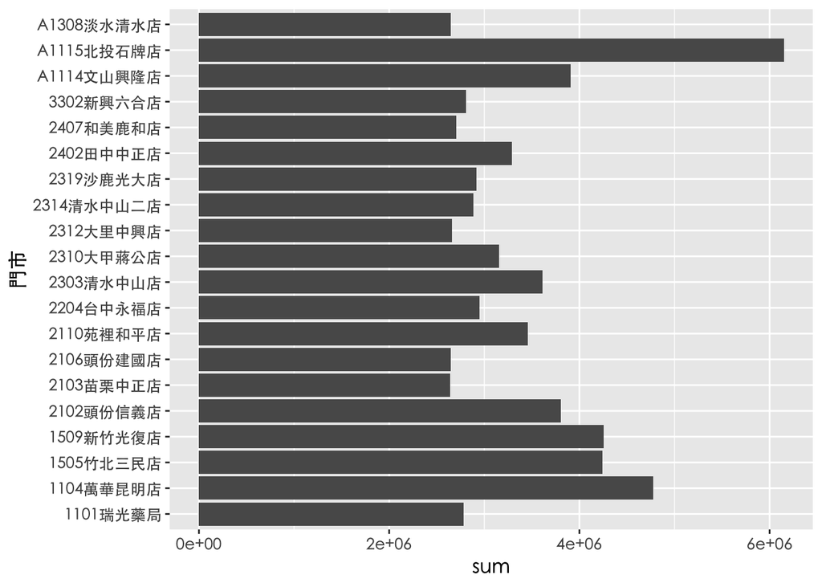

```r
# top10 plot
store.sales = ggplot(head(cvs.1,20), aes(x = 門市, y = sum)) +
  geom_bar(stat = "identity") +
  coord_flip() +
  theme(text=element_text(family="黑體-繁 中黑", size=12))

print(store.sales)
```

### Group by Weekdays

See which day has the most sales number.

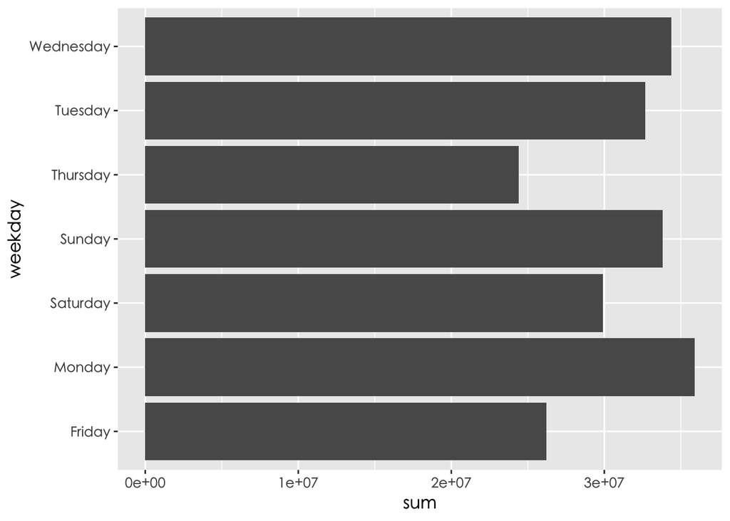

```r
cvs.7 = group_by(cvs, weekday) %>% summarise(sum = sum(營收)) %>% arrange(desc(sum))

# plot
weekday.sales = ggplot(cvs.7, aes(x = weekday, y = sum)) +
  geom_bar(stat = "identity") +
  coord_flip() +
  theme(text=element_text(family="黑體-繁 中黑", size=12))

print(weekday.sales)
```

### Group by Categories

We group the daya by 9 main categories and sum up their sales revenue.

```r
cvs.2 = group_by(cvs, 大分類) %>% summarise(sum = sum(營收)) %>% arrange(desc(sum))
cvs.2
```

```
## # A tibble: 9 x 2
##   大分類       sum
##    <int>     <int>
## 1      1  55926152
## 2      5  37213000
## 3      2  33918320
## 4      6  26277041
## 5      3  23474455
## 6      8  21552697
## 7      4  14459819
## 8      7   8029361
## 9      9  -3527448
```

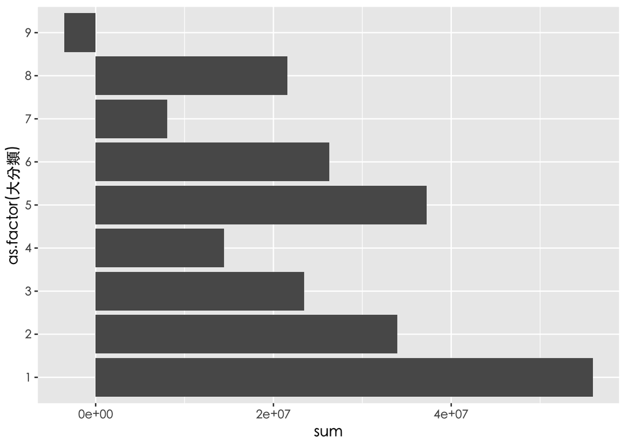

```r
# plot
category.sales = ggplot(cvs.2, aes(x = as.factor(大分類), y = sum)) +
  geom_bar(stat = "identity") +
  theme(text=element_text(family="黑體-繁 中黑", size=12)) +
  coord_flip()

print(category.sales)
```

For category 9 we have negative sales number. In this category we have products like 續點, 現金回饋…We may consider to remove them or treat them independently

Now we break down into detailed product names.

```r
cvs.8 = group_by(cvs, 品名) %>% summarise(sum.qty = sum(數量), sum.rev = sum(營收), unit.rev = sum.rev/sum.qty) %>% arrange(desc(unit.rev))

# top20 (high unit price)
head(cvs.8, 20)
```

```
## # A tibble: 20 x 4
##    品名                                           sum.qty sum.rev unit.rev
##    <chr>                                            <dbl>   <int>    <dbl>
##  1 舒適背巾(方格)#1056/條                               0     144     Inf
##  2 (冷)伊諾娃150                                       20  500000   25000
##  3 (冷)伊諾娃100                                        4   84000   21000
##  4 滋益明Optigold 30mg 300粒/瓶                         7   87120   12446.
##  5 高境界免疫乳漿蛋白禮盒組(10g*30包*3盒+10g*15包*1盒+搖杯*2)…       8   88698   11087.
##  6 KUKU鴨造型床+7件組嬰兒寢具7件組#6003(藍)             1   11025   11025
##  7 神增速Sanolip 300粒/盒                              16  144142    9009.
##  8 中天化療漾口服液180ml/盒                            16  132000    8250
##  9 滋青明Tonox 300粒/瓶                                 9   67833    7537
## 10 亞培基速得(香橙口味)24g*30包/盒                      2   14600    7300
## 11 關立固重陽雙重回饋禮(關立固(加強)軟膠囊200粒2盒+關立固60顆*1+舒逸敏乳油木果油…       4   26946    6736.
## 12 磷能解800mg錠180顆/瓶 中外                           1    6600    6600
## 13 引藻片小球藻2500粒/瓶                                1    6500    6500
## 14 奇哥粉紅俏妞五段式雙向汽座/台                        1    6480    6480
## 15 (冷)果納芬450IU 單支 Gonal-F                        11   67650    6150
## 16 樂伊妥90顆/盒                                       11   63900    5809.
## 17 歐姆龍隧道型手臂式電子血壓計#HEM-1000                2   11050    5525
## 18 " Graco 超輕量型雙向嬰幼兒手推車(粉紅彩)#38000"…       1    5520    5520
## 19 Sympt-x 速養遼280gm 二入禮盒組/組                    5   27000    5400
## 20 東虹第五代敏之素180包/盒                           110  554260    5039.
```

```r
# last20 (low unit price)
tail(cvs.8, 20)
```

```
## # A tibble: 20 x 4
##    品名                                           sum.qty sum.rev unit.rev
##    <chr>                                            <dbl>   <int>    <dbl>
##  1 KUKU消毒鍋#9005/個                                   0       0      NaN
##  2 NEO-TEC妮傲絲翠溫潤保濕潔顏慕斯150ml/瓶              0       0      NaN
##  3 TERUMO ESP-2000 手臂靠墊                             0       0      NaN
##  4 好奇無線感應繽紛吉他/個-好奇1020605-0704買六送贈品…       0       0      NaN
##  5 媽咪小站有機棉哺乳胸罩(85D)#908128                   0       0      NaN
##  6 寶信電動潔鼻機(小鴨造型)                             0       0      NaN
##  7 小不叮小黑蚊驅蚊滾珠乳(全家人適用)100ml/瓶           0       0      NaN
##  8 德國百靈一秒耳溫槍#IRT-4520                          0       0      NaN
##  9 必抑脂膜衣錠2mg單粒(排) (28粒/盒) PITATOR友霖        0       0      NaN
## 10 普美來0.3/1.5mg28s/盒 PREMELL                        0       0      NaN
## 11 杏華鋁製腋下拐(S)#501001-2支/付                      0       0      NaN
## 12 束腰帶M 好家  透氣型 92cm~108                        0       0      NaN
## 13 樂天PEPERO杏仁巧克力棒 36g/盒                        0       0      NaN
## 14 瑪茲桑(黑)200Den3號小腿襪A-D                         0       0      NaN
## 15 立攝適均康均衡香草禮盒                               0       0      NaN
## 16 艾芙美燕麥潔顏油 250ml/罐-贈品10212(需回收)          0       0      NaN
## 17 裁切尿袋+束帶25入/包                                 0       0      NaN
## 18 速樂甜錠 單粒 SULATAN (台灣優                        0       0      NaN
## 19 鋰利靜錠300mg 單粒 LILITIN 利達                      0       0      NaN
## 20 露光點眼液5ml/瓶  SINT杏輝                           0       0      NaN
```

Again, we identified some strange products which deserve a closer look or more discussion.